# Prix de l’immobillier à Nantes

Maxence Rizo

15/11/2021

# Tester mes acquis en analyse de donnée spatiale avec R : les prix à Nantes

## Partie DVF

Premièrement on Extrait de la base DVF les ventes réalisées en 2020 puis on ajoute quelques variables comme le prix au m²

```r
Nantes$pm2<-Nantes$`Valeur fonciere`/Nantes$`Surface Carrez du 1er lot`
Nantes2<-Nantes%>%filter(`Type local`=="Appartement")
```

Ensuite on filtre les petites surfaces qui m’intéressent plus particulièrement, car je cherche à connaitre le premium des studios par rapport aux autres appartements

```r
NantesPS<- Nantes2%>%filter(`Nombre pieces principales`<2)%>%filter(pm2<10000)
```

## Partie GGmap

Ensuite on geocode les adresses de la base précédentes vie GGmap :

```r
#Attention , cela nécéssite une clé API google et est limité à 50 query/s

NantesPS2<-NantesPS%>%mutate(Adresse=paste(`No voie`,`Type de voie`,Voie,`Code postal`,Commune))

#cette commande est longue et nécéssite un accès google, donc je ne l'value pas ici
coord<-geocode(NantesPS2$Adresse)

NantesPS2<-cbind(NantesPS2,coord)
```

Enfin, on projette le tout sur une carte de Nantes en arrière plan :

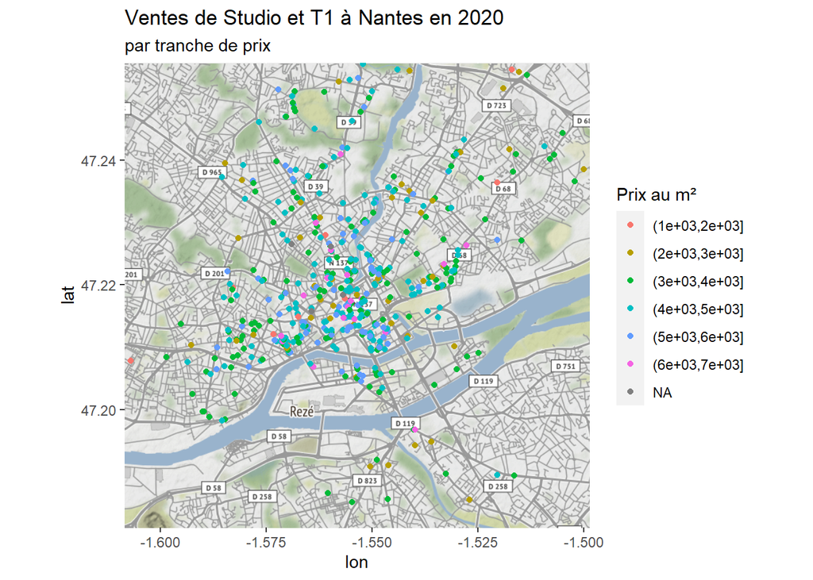

```r
#Coordonnées

nts <- c(lon = -1.553621, lat = 47.218371)

# créations de l'arrière plan

nts_map <- get_map(nts, zoom = 13,source="stamen",maptype="terrain")
#Création de la carte des ventes

ggmap(nts_map) +
  geom_point(aes(lon, lat,color=cut(pm2,c(1000,2000,3000,4000,5000,6000,7000),size=3)), data = NantesPS2)+
  ggtitle("Ventes de Studio et T1 à Nantes en 2020",subtitle = "par tranche de prix")+ labs(color = "Prix au m²")
```

L’analyse est assez intéressante : On voit que le Centre ville présente des prix entre 4000 et 6000 du m² tandis que l’ouest le nord est et l’île de Nantes vont plutot tourner autour de 3000 à 4000 euros. Quelques studios ont été vendues pour moins de 2000 du m² il s’agit sans doute de biens présentatn des travaux importants.

En conclusion, si l’on compare avec les prix affichés par les agences ou sur Leboncoi, on cosntate bien que les vendeurs surévaluent largement le prix des appartements de petite surface par rapport aux prix pratiqués l’an dernier et qu’une négotioation semble souhaitable.